# Exploratory Data Analysis

Pablo Iocco

2/1/2022

## Getting the data

```r
 url  <- "http://d396qusza40orc.cloudfront.net/dsscapstone/dataset/Coursera-SwiftKey.zip"
 if (!file.exists("coursera-swiftkey.zip")){
   download.file(url, destfile="Coursera-Swiftkey.zip")
 }
theFileList=c("final/en_US/en_US.twitter.txt", "final/en_US/en_US.news.txt","final/en_US/en_US.blogs.txt")
unzip("Coursera-Swiftkey.zip", files = theFileList, exdir="en_US", overwrite=TRUE, junkpaths=TRUE)
```

## Basic Summary of the files

```r
library(tokenizers, quietly = TRUE, warn.conflicts = FALSE)
conblog <- file("en_US/en_US.blogs.txt", "r")
blog <-readLines(conblog,encoding="latin1")
close(conblog)

conbnews <- file("en_US/en_US.news.txt", "r")
news<-readLines(conbnews ,encoding="latin1")
close(conbnews)

conbtw<-file("en_US/en_US.twitter.txt", "r")
twitter<-readLines(conbtw,encoding="latin1")
close(conbtw)

labels <- c("en_US.blogs.txt", "en_US.news.txt", "en_US.twitter.txt")
line_counts <- c(length(blog), length(news), length(twitter))
word_counts <- c(sum(count_words(blog)),sum(count_words(news)),sum(count_words(twitter)))
summary = data_frame(labels=labels, lines=line_counts, words=word_counts)
summary
```

```
## # A tibble: 3 × 3
##   labels              lines    words
##   <chr>               <int>    <int>
## 1 en_US.blogs.txt    899288 38153767
## 2 en_US.news.txt    1010242 35016742
## 3 en_US.twitter.txt 2360148 30195678
```

## Sampling

We create 3 variables, *news*, *blogs* and *twitter* which contains samples of 1000 entries of the files `en_US.news.txt`, `en_US.blogs.txt` and `en_US.twitter.txt` respectively.

```r
news <- sample(news, 1000)
blog <- sample(blog, 1000)
twitter <- sample(twitter, 1000)
```

## Tokenize and profanity remove

We get a profanity list that allow us to filter bad words

```r
 if (!file.exists("profanity.txt")){
   download.file("http://www.cs.cmu.edu/~biglou/resources/bad-words.txt", destfile="profanity.txt")
 }
conprofane <- file("profanity.txt", "r")
profane_words <- readLines(conprofane)
```

Now we join the sources of our sample and we tokenize to perform an exploratory analysis.

```r
library(qdap, quietly = TRUE, warn.conflicts = FALSE)
join_sources <- paste(blog,news,twitter)
join_sources <- sent_detect(join_sources, language = "en", model = NULL)
```

```r
library(dplyr, quietly = TRUE, warn.conflicts = FALSE)
library(tidytext, quietly = TRUE, warn.conflicts = FALSE)
text_df <- data_frame(Text = join_sources) %>%
  unnest_tokens(output = word, input = Text)  %>%
  anti_join(stop_words) %>%
  filter(!word %in% profane_words) %>%
  filter(grepl("^[a-zA-Z]+$", word)) %>%
  count(word, sort = TRUE)

total_words<- sum(text_df$n)
text_df <- text_df %>%
  mutate(freq = n/total_words)
```

There are **28505 words** Now will plot the 20 tops words.

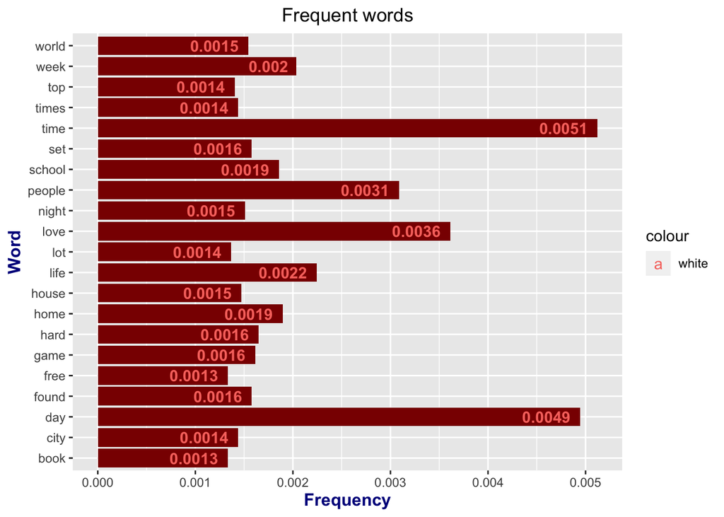

```r
library(ggplot2, quietly = TRUE, warn.conflicts = FALSE)
library(dplyr, quietly = TRUE, warn.conflicts = FALSE)
top_20 <- text_df %>%
  select(freq, word) %>%
  top_n(20, freq)

ggplot(top_20, aes(word,freq)) +
  geom_col(fill = "darkred") +
  coord_flip() +
  labs(x="Word", y="Frequency", title="Frequent words")  +
  geom_text(aes(label = round(freq, 4), hjust = 1.2, colour = "white", fontface = "bold")) +
  theme(plot.title = element_text(hjust = 0.5),
        axis.title.x = element_text(face="bold", colour = "darkblue", size=12),
        axis.title.y = element_text(face="bold", colour = "darkblue", size=12))
```

So must popular words are *time* and *day* which is expected from news and blog sources, and also sentiments like `love` which is what you expect in twitter

We see that top 10 words account for **2.81%**

Top 100 words account for **12.99%**

Top 1000 words account for **44.1%**

Top 2000 words account for **64.53%**

## Next Steps

In the next report we will work on:

```
N-Grams for full data sets
Strategy for combination that doesnt exists on N-Grams
Optimize model for low memory utilization
Implement app on Shiny
```